# Pembangkitan Autoregressive dan Moving Average

Pertemuan kali ini akan melakukan proses ARIMA pada kestasioneran data time series

## White Noise

Dimulai dengan membangkitkan data normal secara acak sejumlah 300 amatan sebagai data time series atau selanjutnya dianggap sebagai white noise.

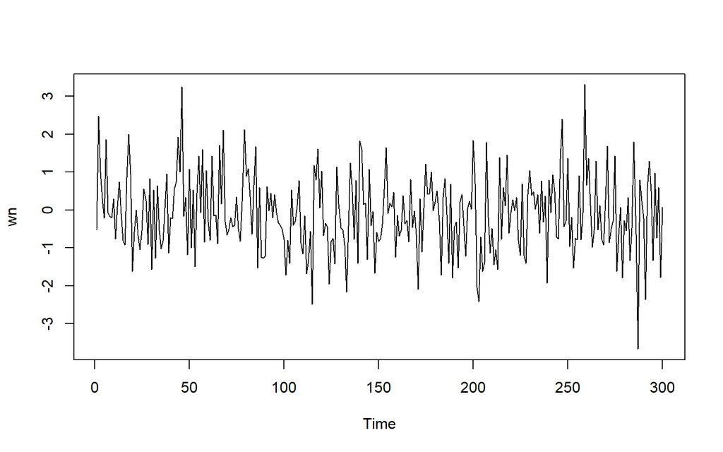

```r
set.seed(022)
wn <- rnorm(300)
ts.plot(wn)
```

## Proses MA

### Pembangkitan Proses MA(2)

Akan dicoba membangkitkan proses MA sederhana, yaitu MA(2) dengan $\theta_1 = 0.4$ dan $\theta_2 = 0.6$ sebanyak 300 observasi dan $c=0$. Karena diperlukan satu nilai awal untuk $e_{t-1}$ dan $e_{t-2}$, masukkan nilai pertama white noise sebagai nilai awal tersebut.

```r
ma2 <- wn[c(1,2)]
```

Nilai-nilai selanjutnya dapat dicari melalui loop. Bentuk loop dapat dilihat dari rumus MA(2) yang hendak dibangkitkan:

$$y_t =
e_t+0.4e_{t-1}+0.6e_{t-2}$$

#### Cara Manual

```r
for(i in 3:300){
   ma2[i] <- wn[i] + 0.4 * wn[i - 1] + 0.6 * wn[i - 2]
}
ma2
```

[output not shown]

[output cut: 35 more lines]

#### Fungs arima.sim

```r
ma2 <- arima.sim(list(order=c(0,0,2), ma=c(0.4,0.6)), n=300)
ma2
```

[output not shown]

[output cut: 49 more lines]

### Karakteristik MA(2)

#### Plot Time Series

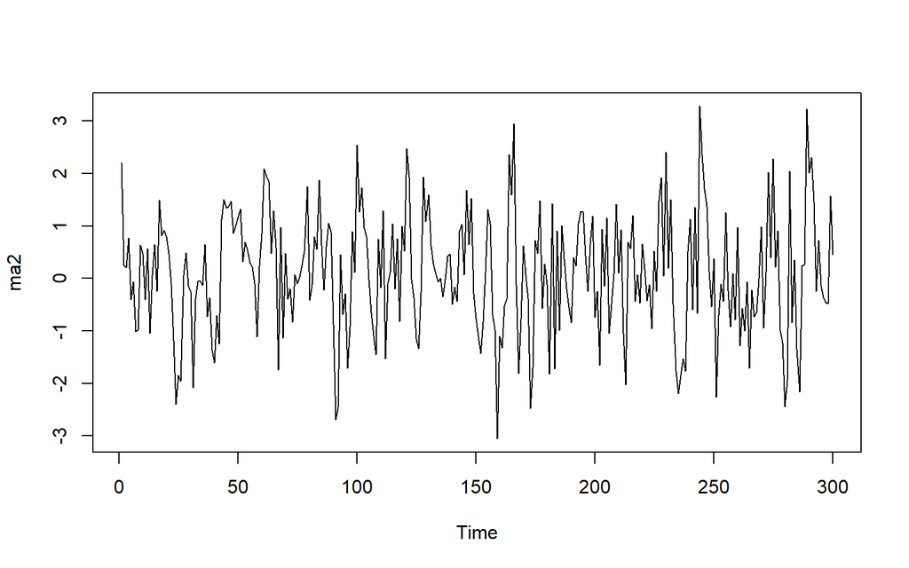

```r
ts.plot(ma2)
```

Berdasarkan plot time series, terlihat bahwa data MA(2) yang dibangkitkan stasioner dalam rataan

#### Plot ACF

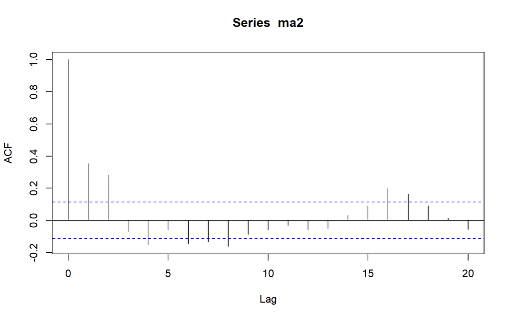

```r
acf(ma2,lag.max = 20)
```

Berdasarkan plot AFC tersebut, terlihat bahwa plot ACF *cuts off* setelah lag kedua maka ini menandakan MA(2)

#### Plot PACF

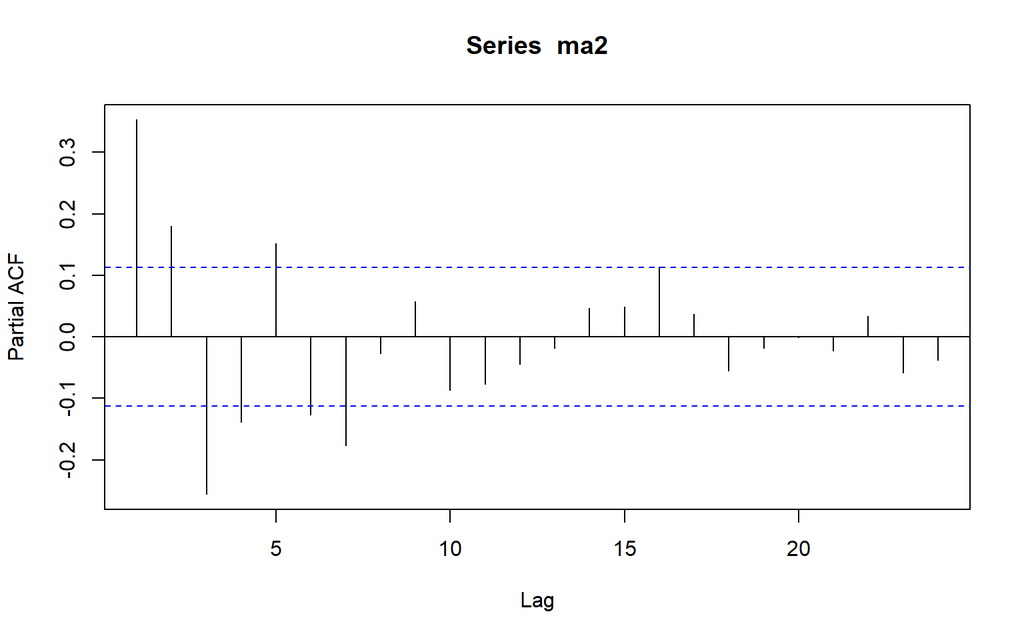

```r
pacf(ma2)
```

Berdasarkan plot PACF tersebut, terlihat bahwa plot PACF cenderung *tails off* dan membentuk gelombang sinus yang artinya menandakan MA(2) tadi atau disini didapat AR(0)

#### Plot EACF

```r
TSA::eacf(ma2)
```

```
## AR/MA
##   0 1 2 3 4 5 6 7 8 9 10 11 12 13
## 0 x x o x o x x x o o o  o  o  o
## 1 x x x x o o o o o o o  o  o  o
## 2 x x o x o o o o o o o  o  o  o
## 3 x x o x o o o o o o o  o  o  o
## 4 x o x x o x o o o o o  o  o  o
## 5 x o x x x x o o o o o  o  o  o
## 6 x x o x o x o o o o o  o  o  o
## 7 x x o x x x o x o o o  o  o  o
```

### Scatterplot Antar Peubah Lag

#### Korelasi antara $Y_t$ dengan $Y_{t-1}$

```r
#Yt
yt_ma2 <- ma2[-1]
yt_ma2
```

[output not shown]

[output cut: 45 more lines]

```r
#Yt-1
yt_1_ma2 <- ma2[-300]
yt_1_ma2
```

[output not shown]

[output cut: 45 more lines]

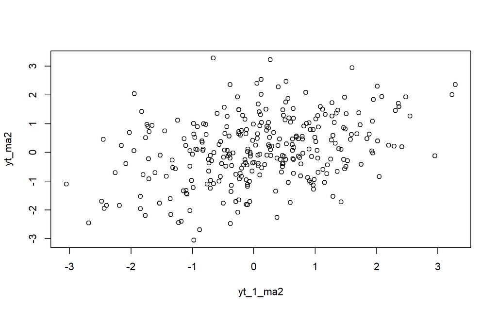

```r
plot(y=yt_ma2,x=yt_1_ma2)
```

Berdasarkan scatterplot tersebut, terlihat bahwa terdapat hubungan positif yang rendah antara $Y_t$ dengan $Y_{t-1}$.

```r
cor(yt_ma2,yt_1_ma2)
```

```
## [1] 0.3551089
```

#### Korelasi antara $Y_t$ dengan $Y_{t-2}$

```r
#Yt
yt_ma2.2 <- ma2[-c(1,2)]
yt_ma2.2
```

[output not shown]

[output cut: 45 more lines]

```r
#Yt-2
yt_2_ma2 <- ma2[-c(299,300)]
yt_2_ma2
```

[output not shown]

[output cut: 45 more lines]

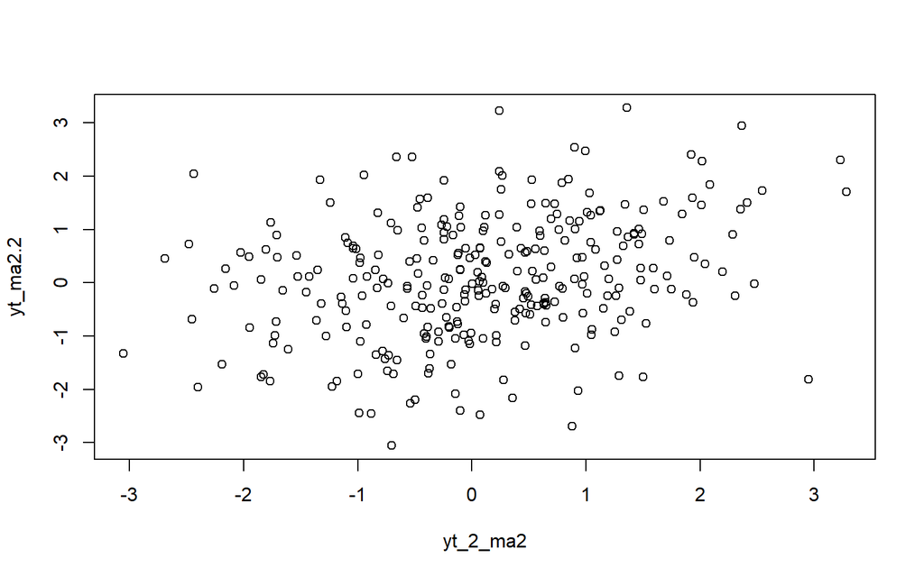

```r
plot(y=yt_ma2.2,x=yt_2_ma2)
```

Berdasarkan scatterplot tersebut, terlihat bahwa cenderung hubungan rendah antara $Y_t$ dengan $Y_{t-2}$.

```r
cor(yt_ma2.2,yt_2_ma2)
```

```
## [1] 0.2844754
```

#### Korelasi antara $Y_t$ dengan $Y_{t-3}$

```r
#Yt
yt_ma2.3 <- ma2[-c(1,2,3)]
yt_ma2.3
```

[output not shown]

[output cut: 45 more lines]

```r
#Yt-2
yt_3_ma2 <- ma2[-c(298,299,300)]
yt_3_ma2
```

[output not shown]

[output cut: 45 more lines]

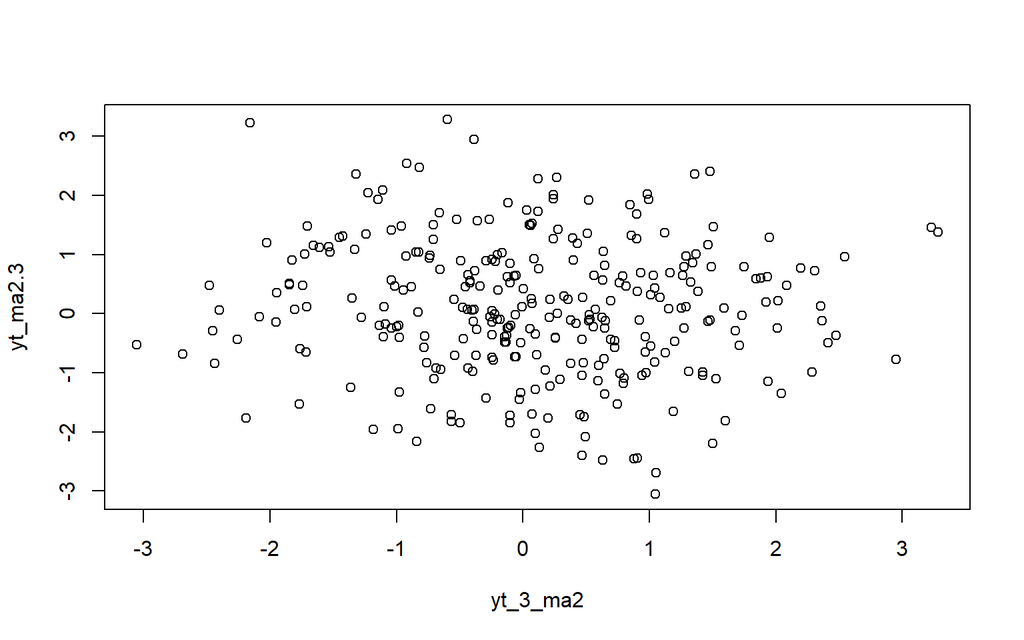

```r
plot(y=yt_ma2.3,x=yt_3_ma2)
```

Berdasarkan scatterplot tersebut, terlihat bahwa cenderung tidak terdapat hubungan antara $Y_t$ dengan $Y_{t-3}$.

```r
cor(yt_ma2.3,yt_3_ma2)
```

```
## [1] -0.07238159
```

#### Perbandingan korelasi $Yt_t$ dengan $Y_{t-1}$, $Yt_t$ dengan $Y_{t-2}$, & $Yt_t$ dengan $Y_{t-3}$

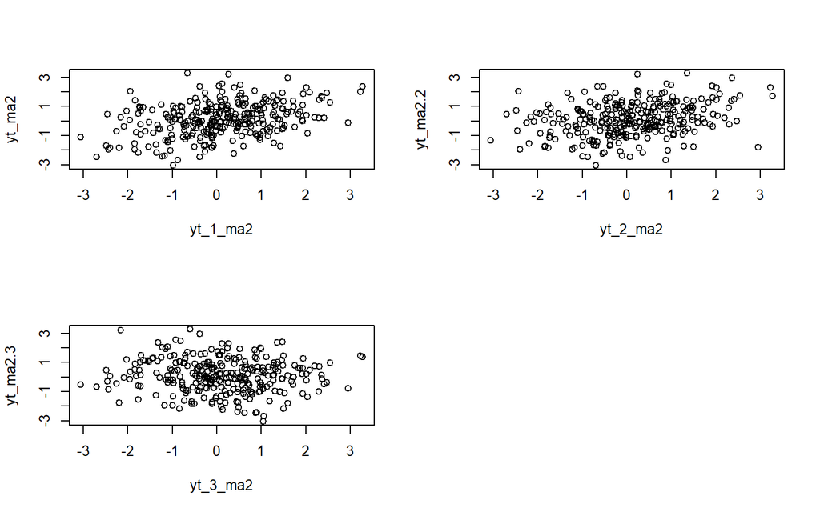

```r
par(mfrow=c(2,2))
plot(y=yt_ma2,x=yt_1_ma2)
plot(y=yt_ma2.2,x=yt_2_ma2)
plot(y=yt_ma2.3,x=yt_3_ma2)
```

## Proses AR

### Pembangkitan Proses AR(2)

Akan dicoba membangkitkan proses AR paling sederhana, yaitu AR(2) dengan $\phi_1 = 0.5$ dan $\phi_2 = 0.2$ sebanyak 300 observasi dan $c=0$.

$$Y_t = e_t+0.5Y_{t-1}+0.2Y_{t-2}$$

#### Cara Manual

```r
n<-length(wn)
n
```

```
## [1] 300
```

```r
ar2 <- c(2:n)
for (i in 3:n) {ar2[i]<-wn[i]+0.5*ar2[i-1]+0.2*ar2[i-2]}
ar2
```

[output not shown]

[output cut: 45 more lines]

#### Fungsi arima.sim

```r
ar2 <- arima.sim(list(order=c(2,0,0), ar=c(0.5,0.2)), n=300)
ar2
```

[output not shown]

[output cut: 49 more lines]

### Karakteristik AR(2)

#### Plot Time Series

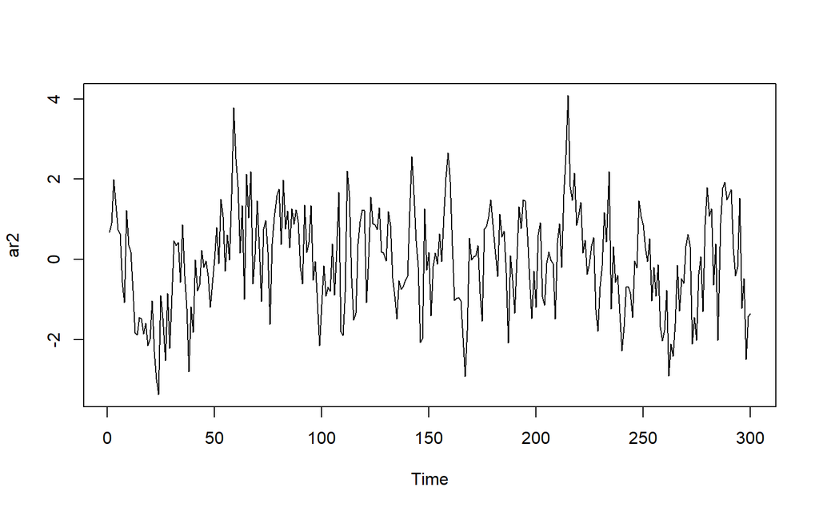

```r
ts.plot(ar2)
```

Berdasarkan plot time series tersebut terlihat bahwa data cenderung stasioner pada rataan

#### Plot ACF

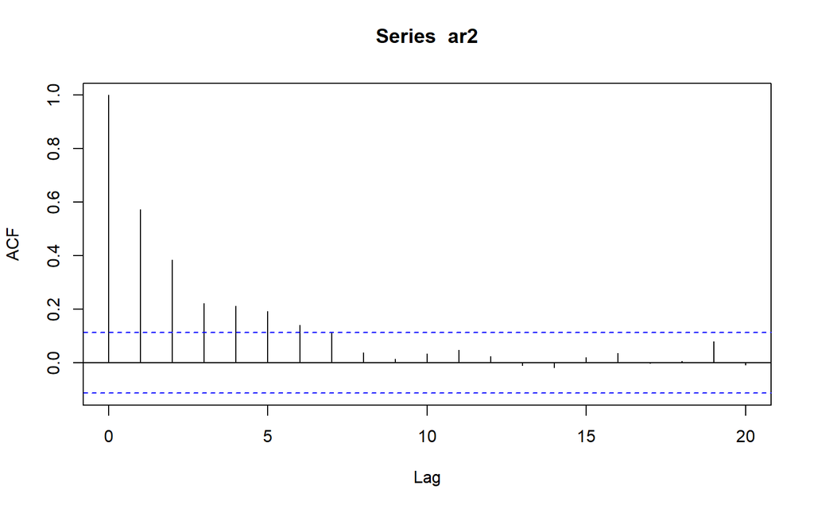

```r
acf(ar2,lag.max = 20)
```

Berdasarkan plot AFC tersebut, terlihat bahwa plot ACF *tells off* penanda model adalah AR

#### Plot PACF

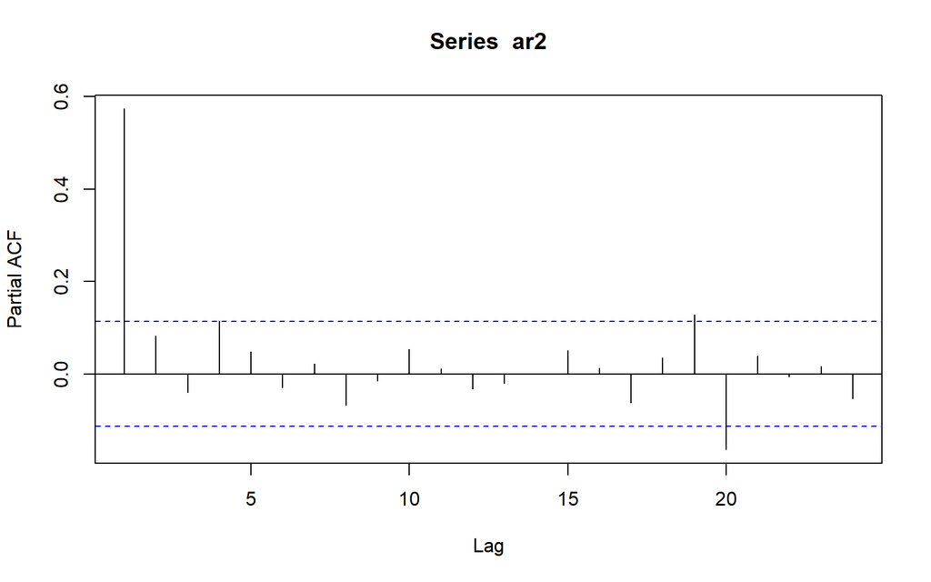

```r
pacf(ar2)
```

#### Plot EACF

```r
TSA::eacf(ar2)
```

```
## AR/MA
##   0 1 2 3 4 5 6 7 8 9 10 11 12 13
## 0 x x x x x x o o o o o  o  o  o
## 1 x o x o o o o o o o o  o  o  o
## 2 x o x o o o o o o o o  o  o  o
## 3 x x x o o o o o o o o  o  o  o
## 4 x x x o o o o o o o o  o  o  o
## 5 x o o x o o o o o o o  o  o  o
## 6 x o o x x o o o o o o  o  o  o
## 7 x x x x x o x o o o o  o  o  o
```

### Scatterplot Antar Peubah Lag

#### Korelasi antara $Y_t$ dengan $Y_{t-1}$

```r
#Yt
yt_ar2 <- ar2[-1]
yt_ar2
```

[output not shown]

[output cut: 45 more lines]

```r
#Yt-1
yt_1_ar2 <- ar2[-300]
yt_1_ar2
```

[output not shown]

[output cut: 45 more lines]

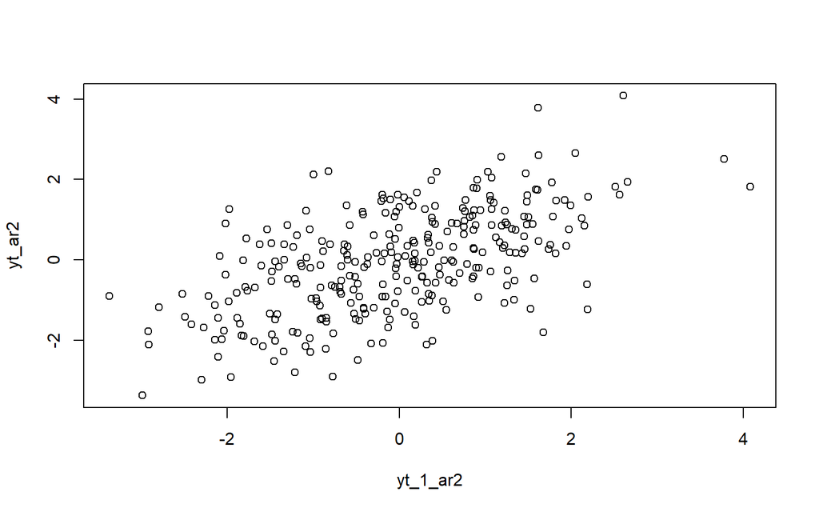

```r
plot(y=yt_ar2,x=yt_1_ar2)
```

Berdasarkan scatterplot tersebut, terlihat bahwa terdapat hubungan positif antara $Y_t$ dengan $Y_{t-1}$.

```r
cor(yt_ar2,yt_1_ar2)
```

```
## [1] 0.5745402
```

#### Korelasi antara $Y_t$ dengan $Y_{t-2}$

```r
#Yt
yt_ar2.2 <- ar2[-c(1,2)]
yt_ar2.2
```

[output not shown]

[output cut: 45 more lines]

```r
#Yt-2
yt_2_ar2 <- ar2[-c(299,300)]
yt_2_ar2
```

[output not shown]

[output cut: 45 more lines]

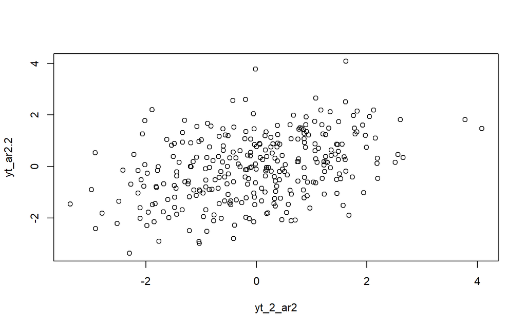

```r
plot(y=yt_ar2.2,x=yt_2_ar2)
```

Berdasarkan scatterplot tersebut, terlihat bahwa terdapat hubungan positif antara $Y_t$ dengan $Y_{t-2}$.

```r
cor(yt_ar2.2,yt_2_ar2)
```

```
## [1] 0.3859049
```

#### Korelasi antara $Y_t$ dengan $Y_{t-3}$

```r
#Yt
yt_ar2.3 <- ar2[-c(1,2,3)]
yt_ar2.3
```

[output not shown]

[output cut: 45 more lines]

```r
#Yt-2
yt_3_ar2 <- ar2[-c(298,299,300)]
yt_3_ar2
```

[output not shown]

[output cut: 45 more lines]

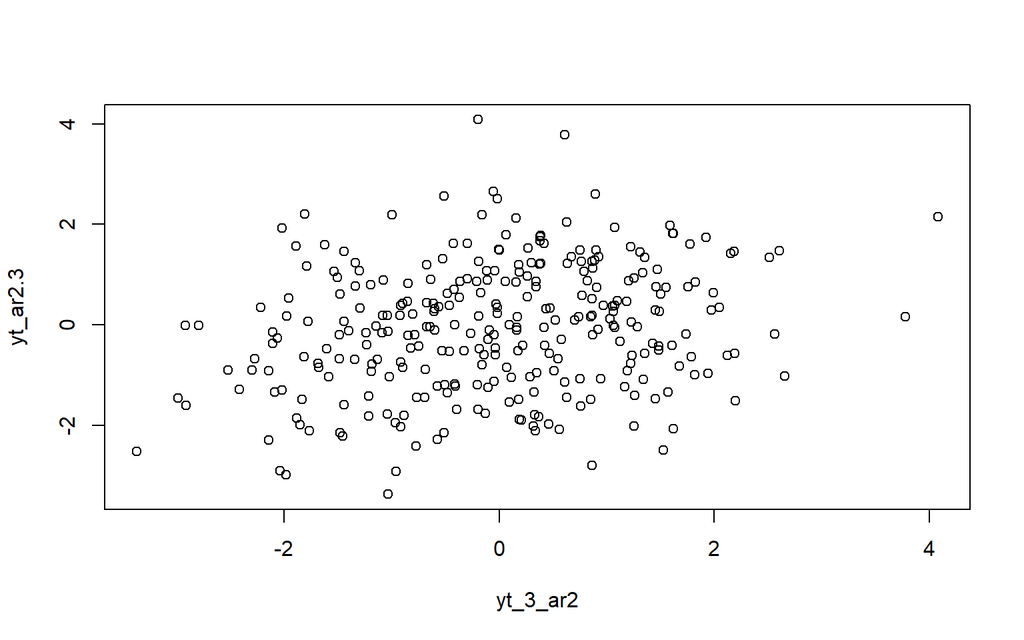

```r
plot(y=yt_ar2.3,x=yt_3_ar2)
```

Berdasarkan scatterplot tersebut, terlihat bahwa terdapat hubungan lemah antara $Y_t$ dengan $Y_{t-3}$.

```r
cor(yt_ar2.3,yt_3_ar2)
```

```
## [1] 0.2264197
```

#### Perbandingan korelasi $Yt_t$ dengan $Y_{t-1}$, $Yt_t$ dengan $Y_{t-2}$, & $Yt_t$ dengan $Y_{t-3}$

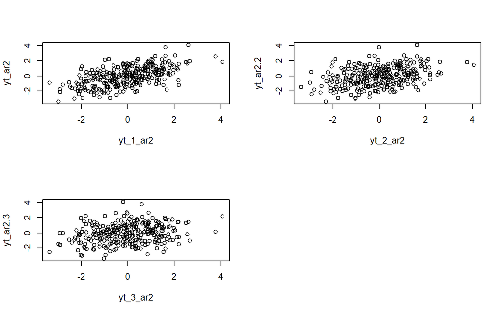

```r
par(mfrow=c(2,2))
plot(y=yt_ar2,x=yt_1_ar2)
plot(y=yt_ar2.2,x=yt_2_ar2)
plot(y=yt_ar2.3,x=yt_3_ar2)
```

## Proses ARMA

### Pembangkitan Proses ARMA(2,2)

#### Cara Manual

```r
y.arma=c(1:n)
for (i in 3:n){y.arma[i] = 0.5*y.arma[i-1] + 0.2*y.arma[i-2] + 0.4*wn[i-1]+  0.6*wn[i-2]+wn[i]}
```

#### Fungsi arima.sim

```r
arma22 <- arima.sim(list(order=c(2,0,2), ar = c(0.5,0.2), ma = c(0.5,0.2)), n=300)
arma22
```

[output not shown]

[output cut: 39 more lines]

### Karakteristik ARMA(2,2)

#### Plot Time Series

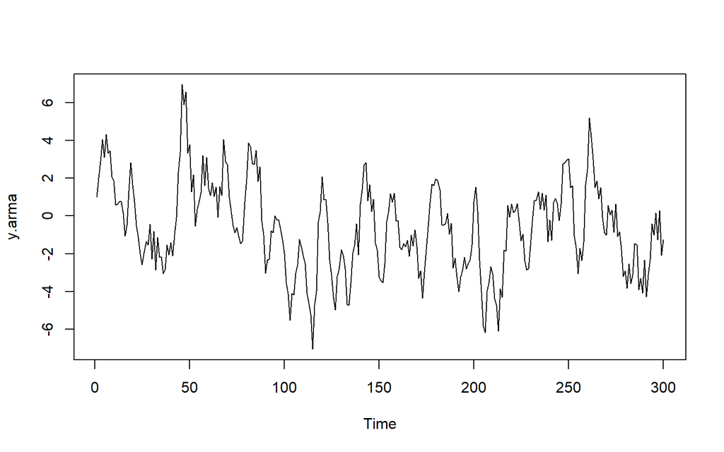

```r
ts.plot(y.arma)
```

Berdasarkan plot time series tersebut, terlihat bahwa model ARMA(2,2) cenderung stasioner dalam rataan

#### Plot ACF

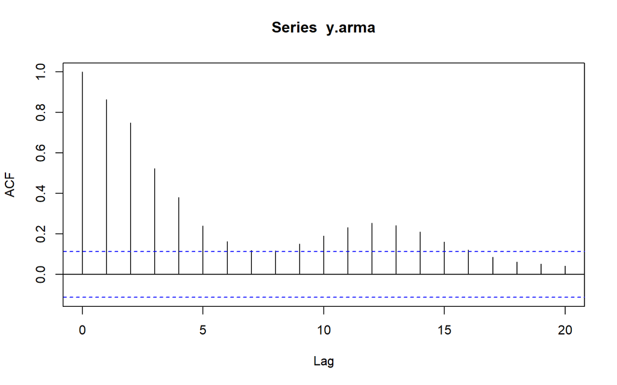

```r
acf(y.arma,lag.max = 20)
```

Berdasarkan plot ACF tersebut, terlihat bahwa model ARMA(2,2) hasil simulasi memiliki plot ACF yang *tails off*

#### Plot PACF

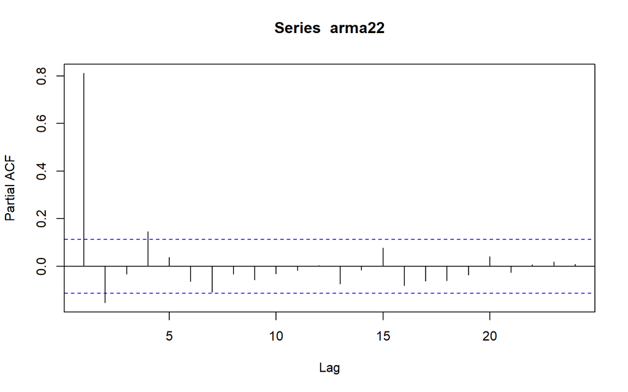

```r
pacf(arma22)
```

#### Plot EACF

```r
TSA::eacf(arma22)
```

```
## AR/MA
##   0 1 2 3 4 5 6 7 8 9 10 11 12 13
## 0 x x x x x x x o o o o  o  x  x
## 1 x o x o o x o o o o o  o  o  o
## 2 x o x x o x o o o o o  o  o  o
## 3 x x o o o x o o o o o  o  o  o
## 4 x x x o o x o o o o o  o  o  o
## 5 x x x x o o o o o o o  o  o  o
## 6 x x x x o o o o o o o  o  o  o
## 7 x x x o x o o o o o o  o  o  o
```

### Scatterplot Antar Peubah Lag

#### Korelasi antara $Y_t$ dengan $Y_{t-1}$

```r
#Yt
yt_arma22 <- arma22[-1]
yt_arma22
```

[output not shown]

[output cut: 35 more lines]

```r
#Yt-1
yt_1_arma22 <- arma22[-300]
yt_1_arma22
```

[output not shown]

[output cut: 35 more lines]

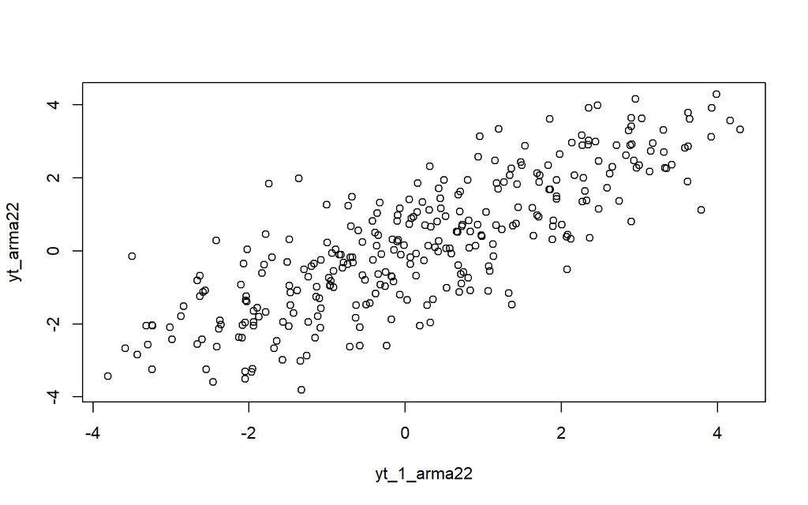

```r
plot(y=yt_arma22,x=yt_1_arma22)
```

Berdasarkan scatterplot tersebut, terlihat bahwa terdapat hubungan positif antara $Y_t$ dengan $Y_{t-1}$.

```r
cor(yt_arma22,yt_1_arma22)
```

```
## [1] 0.8123794
```

#### Korelasi antara $Y_t$ dengan $Y_{t-2}$

```r
#Yt
yt_arma22.2 <- arma22[-c(1,2)]
yt_arma22.2
```

[output not shown]

[output cut: 35 more lines]

```r
#Yt-2
yt_2_arma22 <- arma22[-c(299,300)]
yt_2_arma22
```

[output not shown]

[output cut: 35 more lines]

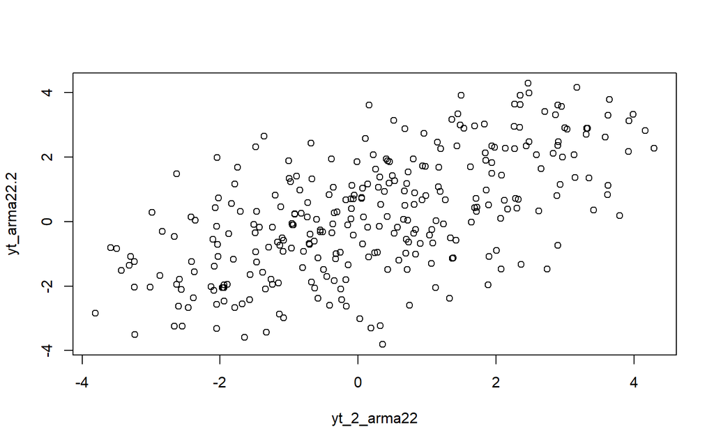

```r
plot(y=yt_arma22.2,x=yt_2_arma22)
```

Berdasarkan scatterplot tersebut, terlihat bahwa terdapat hubungan positif antara $Y_t$ dengan $Y_{t-2}$.

```r
cor(yt_arma22.2,yt_2_arma22)
```

```
## [1] 0.6070096
```

#### Korelasi antara $Y_t$ dengan $Y_{t-3}$

```r
#Yt
yt_arma22.3 <- arma22[-c(1,2,3)]
yt_arma22.3
```

[output not shown]

[output cut: 35 more lines]

```r
#Yt-2
yt_3_arma22 <- arma22[-c(298,299,300)]
yt_3_arma22
```

[output not shown]

[output cut: 35 more lines]

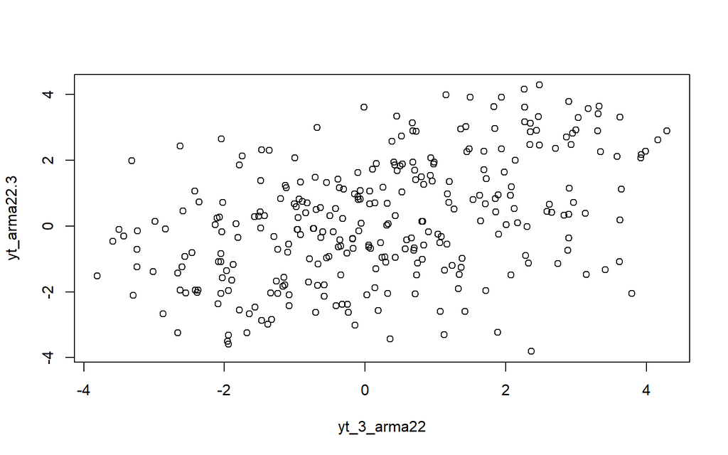

```r
plot(y=yt_arma22.3,x=yt_3_arma22)
```

Berdasarkan scatterplot tersebut, terlihat bahwa terdapat hubungan positif antara $Y_t$ dengan $Y_{t-3}$. Hal ini sesuai dengan teori yang ada

```r
cor(yt_arma22.3,yt_3_arma22)
```

```
## [1] 0.433211
```

#### Perbandingan korelasi $Yt_t$ dengan $Y_{t-1}$, $Yt_t$ dengan $Y_{t-2}$, & $Yt_t$ dengan $Y_{t-3}$

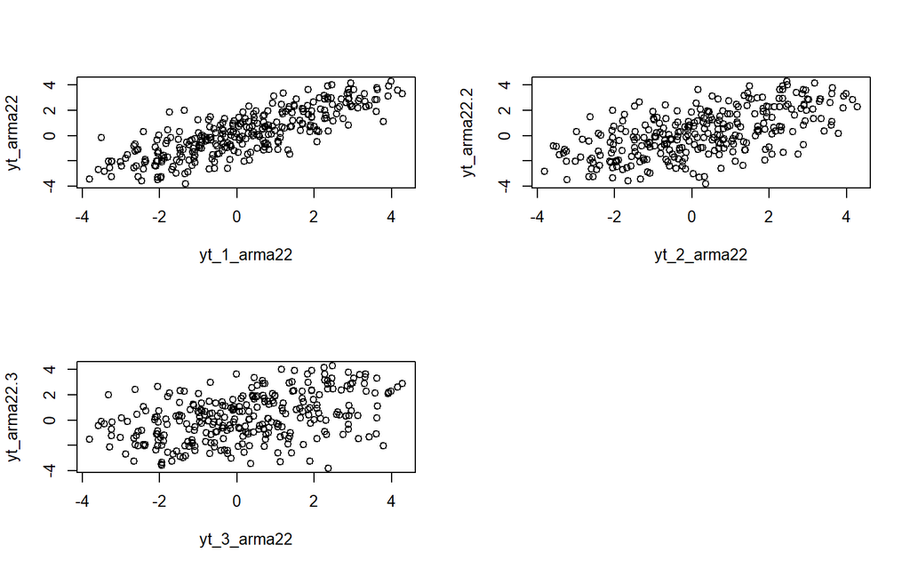

```r
par(mfrow=c(2,2))
plot(y=yt_arma22,x=yt_1_arma22)
plot(y=yt_arma22.2,x=yt_2_arma22)
plot(y=yt_arma22.3,x=yt_3_arma22)
```